# 4545 Team League: Season 27

### Openings stats

#### Top openings (broad)

All openings played in the season, excluding variations.

| Rank | Opening | Games | White % | 1-0 % | Draw % | 0-1 % | Mean Eval | Avg Rating |
| --- | --- | --- | --- | --- | --- | --- | --- | --- |
| 1 | Sicilian Defense | 312 | 52.2435897435897 | 45.1923076923077 | 14.1025641025641 | 40.7051282051282 | 0.831842105263158 | 1891.71955128205 |
| 2 | Caro-Kann Defense | 162 | 49.3827160493827 | 43.2098765432099 | 12.3456790123457 | 44.4444444444444 | 0.71 | 1810.17592592593 |
| 3 | French Defense | 97 | 56.1855670103093 | 51.5463917525773 | 9.27835051546392 | 39.1752577319588 | 1.47457446808511 | 1814.13402061856 |
| 4 | English Opening | 93 | 46.2365591397849 | 37.6344086021505 | 17.2043010752688 | 45.1612903225806 | 0.590879120879121 | 1862.7688172043 |
| 5 | Queen's Gambit Declined | 74 | 60.8108108108108 | 52.7027027027027 | 16.2162162162162 | 31.0810810810811 | 1.23972972972973 | 1803.78378378378 |
| 6 | Indian Defense | 69 | 54.3478260869565 | 44.9275362318841 | 18.8405797101449 | 36.231884057971 | 0.481911764705882 | 1893.83333333333 |
| 7 | Queen's Pawn Game | 64 | 50 | 43.75 | 12.5 | 43.75 | 0.02953125 | 1855.1328125 |
| 8 | Ruy Lopez | 60 | 51.6666666666667 | 45 | 13.3333333333333 | 41.6666666666667 | 0.488983050847458 | 1881.63333333333 |
| 9 | Italian Game | 54 | 52.7777777777778 | 46.2962962962963 | 12.962962962963 | 40.7407407407407 | 0.657037037037037 | 1848.18518518519 |
| 10 | Slav Defense | 45 | 62.2222222222222 | 55.5555555555556 | 13.3333333333333 | 31.1111111111111 | 0.332272727272727 | 1830.32222222222 |

[output cut: 61 more lines]

#### Top lines

All openings played in the season, including variations.

| Rank | Opening | Games | White % | 1-0 % | Draw % | 0-1 % | Mean Eval | Avg Rating |
| --- | --- | --- | --- | --- | --- | --- | --- | --- |
| 1 | Indian Defense | 35 | 54.2857142857143 | 42.8571428571429 | 22.8571428571429 | 34.2857142857143 | 0.0131428571428571 | 1872.15714285714 |
| 2 | Caro-Kann Defense: Advance Variation, Tal Variation | 20 | 50 | 45 | 10 | 45 | 1.88315789473684 | 1892.075 |
| 2 | Sicilian Defense: Closed | 20 | 55 | 40 | 30 | 30 | 1.16222222222222 | 1897.275 |
| 3 | Scandinavian Defense: Mieses-Kotroc Variation | 18 | 55.5555555555556 | 44.4444444444444 | 22.2222222222222 | 33.3333333333333 | 0.5 | 1746.94444444444 |
| 4 | Caro-Kann Defense: Exchange Variation | 17 | 64.7058823529412 | 58.8235294117647 | 11.7647058823529 | 29.4117647058824 | 2.04411764705882 | 1795.67647058824 |
| 4 | Caro-Kann Defense: Maróczy Variation | 17 | 50 | 41.1764705882353 | 17.6470588235294 | 41.1764705882353 | -0.65375 | 1835.08823529412 |
| 4 | Sicilian Defense: Alapin Variation | 17 | 61.7647058823529 | 58.8235294117647 | 5.88235294117647 | 35.2941176470588 | 1.48588235294118 | 1857.02941176471 |
| 4 | Sicilian Defense: Najdorf Variation | 17 | 58.8235294117647 | 58.8235294117647 | 0 | 41.1764705882353 | 0.704705882352941 | 1922.64705882353 |
| 5 | Pirc Defense | 14 | 39.2857142857143 | 28.5714285714286 | 21.4285714285714 | 50 | -1.01285714285714 | 1856.42857142857 |
| 6 | Queen's Pawn Game: Mason Variation | 13 | 42.3076923076923 | 30.7692307692308 | 23.0769230769231 | 46.1538461538462 | 0.451538461538462 | 1828.11538461538 |

[output cut: 597 more lines]

#### Best for White

The best-scoring main openings for White.

*Includes all main openings played in at least 10 games.*

| Rank | Opening | Games | White's score (%) | White wins (%) | Draws (%) | Black wins (%) | Mean eval after 15 moves | Avg rating |
| --- | --- | --- | --- | --- | --- | --- | --- | --- |
| 1 | Zukertort Opening | 16 | 65.625 | 56.25 | 18.75 | 25 | 0.745 | 1848.53125 |
| 2 | Slav Defense | 45 | 62.2222222222222 | 55.5555555555556 | 13.3333333333333 | 31.1111111111111 | 0.332272727272727 | 1830.32222222222 |
| 3 | Benko Gambit Accepted | 13 | 61.5384615384615 | 61.5384615384615 | 0 | 38.4615384615385 | 1.44923076923077 | 1967.73076923077 |
| 4 | Queen's Gambit Declined | 74 | 60.8108108108108 | 52.7027027027027 | 16.2162162162162 | 31.0810810810811 | 1.23972972972973 | 1803.78378378378 |
| 5 | Alekhine Defense | 18 | 58.3333333333333 | 50 | 16.6666666666667 | 33.3333333333333 | 0.541176470588235 | 1868.08333333333 |
| 5 | Grünfeld Defense | 18 | 58.3333333333333 | 38.8888888888889 | 38.8888888888889 | 22.2222222222222 | 1.10529411764706 | 1909.55555555556 |
| 6 | French Defense | 97 | 56.1855670103093 | 51.5463917525773 | 9.27835051546392 | 39.1752577319588 | 1.47457446808511 | 1814.13402061856 |
| 7 | Scandinavian Defense | 38 | 55.2631578947368 | 44.7368421052632 | 21.0526315789474 | 34.2105263157895 | 1.18378378378378 | 1769.30263157895 |
| 8 | Nimzo-Larsen Attack | 21 | 54.7619047619048 | 42.8571428571429 | 23.8095238095238 | 33.3333333333333 | 0.386 | 1822.07142857143 |
| 9 | Four Knights Game | 22 | 54.5454545454545 | 54.5454545454545 | 0 | 45.4545454545455 | 1.3085 | 1762.77272727273 |

[output cut: 20 more lines]

#### Best for Black

The best-scoring main openings for Black.

*Includes all main openings played in at least 10 games.*

| Rank | Opening | Games | Black's score (%) | Black wins (%) | Draws (%) | White wins (%) | Mean eval after 15 moves | Avg rating |
| --- | --- | --- | --- | --- | --- | --- | --- | --- |
| 1 | Dutch Defense | 15 | 63.3333333333333 | 53.3333333333333 | 20 | 26.6666666666667 | 0.242 | 1956.16666666667 |
| 2 | Neo-Grünfeld Defense | 15 | 60 | 40 | 40 | 20 | -0.082 | 2008.46666666667 |
| 3 | Queen's Indian Defense | 11 | 59.0909090909091 | 45.4545454545455 | 27.2727272727273 | 27.2727272727273 | 0.529090909090909 | 1911.81818181818 |
| 4 | Bird Opening | 13 | 57.6923076923077 | 53.8461538461538 | 7.69230769230769 | 38.4615384615385 | 0.4175 | 2045.46153846154 |
| 5 | Pirc Defense | 24 | 56.25 | 45.8333333333333 | 20.8333333333333 | 33.3333333333333 | -0.642608695652174 | 1818.66666666667 |
| 6 | Catalan Opening | 13 | 53.8461538461538 | 38.4615384615385 | 30.7692307692308 | 30.7692307692308 | -0.685384615384615 | 1964.46153846154 |
| 7 | English Opening | 93 | 53.763440860215 | 45.1612903225806 | 17.2043010752688 | 37.6344086021505 | 0.590879120879121 | 1862.7688172043 |
| 8 | King's Indian Defense | 44 | 53.4090909090909 | 47.7272727272727 | 11.3636363636364 | 40.9090909090909 | 0.972093023255814 | 1874.01136363636 |
| 9 | Scotch Game | 31 | 53.2258064516129 | 51.6129032258064 | 3.2258064516129 | 45.1612903225806 | 0.544333333333333 | 1822.3064516129 |
| 10 | Caro-Kann Defense | 162 | 50.6172839506173 | 44.4444444444444 | 12.3456790123457 | 43.2098765432099 | 0.71 | 1810.17592592593 |

[output cut: 20 more lines]

#### Top gambits

All gambits played in the season.[^5]

| Rank | Name | Games | White score (%) |
| --- | --- | --- | --- |
| 1 | Benko Gambit | 13 | 38.4615384615385 |
| 2 | Polerio Defense (Two Knights) | 10 | 50 |
| 3 | Scotch Gambit | 10 | 35 |
| 4 | Queen's Gambit Accepted | 7 | 35.7142857142857 |
| 5 | Smith-Morra Gambit | 6 | 50 |
| 6 | Evans Gambit | 6 | 25 |
| 7 | Budapest Defense | 5 | 20 |
| 8 | Greco Gambit | 4 | 62.5 |
| 9 | Vienna Gambit | 4 | 25 |
| 10 | Geller Gambit | 3 | 66.6666666666667 |

[output cut: 34 more lines]

#### Gambiteers 🤺

The players who enjoyed the most success when playing gambits.[^6]

*Shows all players who scored at least 50% playing gambits in the season (min. games: 2).*

| Rank | Player | Games | % Score | W | B | Choices |
| --- | --- | --- | --- | --- | --- | --- |
| 1 | MrScribbles | 4 | 100 | 4 | 0 | Halloween Gambit, Gibbins-Wiedenhagen Gambit, Shirov Gambit |
| 2 | BattleAxiom | 3 | 83.3333333333333 | 0 | 3 | Stafford Gambit, Budapest Defense |
| 3 | KaperKK | 3 | 66.6666666666667 | 1 | 2 | Benko Gambit, Polerio Defense (Two Knights) |
| 3 | scvrf | 3 | 66.6666666666667 | 1 | 2 | Benko Gambit, Shirov Gambit |
| 3 | Seb32 | 3 | 66.6666666666667 | 1 | 2 | Ruy Lopez: Marshall Attack, Ulvestad Variation (Two Knights), Danish Gambit |
| 4 | root2 | 2 | 100 | 2 | 0 | Scotch Gambit |
| 5 | Kolskegg | 2 | 75 | 2 | 0 | King's Gambit, Smith-Morra Gambit |
| 6 | APDent42 | 2 | 50 | 0 | 2 | Polerio Defense (Two Knights) |
| 6 | Artian12 | 2 | 50 | 1 | 1 | Greco Gambit, Budapest Defense |
| 6 | Juggles8 | 2 | 50 | 2 | 0 | Smith-Morra Gambit |

[output cut: 1 more lines]

### Openings sunburst 🌞

Click on the image below to see a sunburst plot of all openings played in the season.

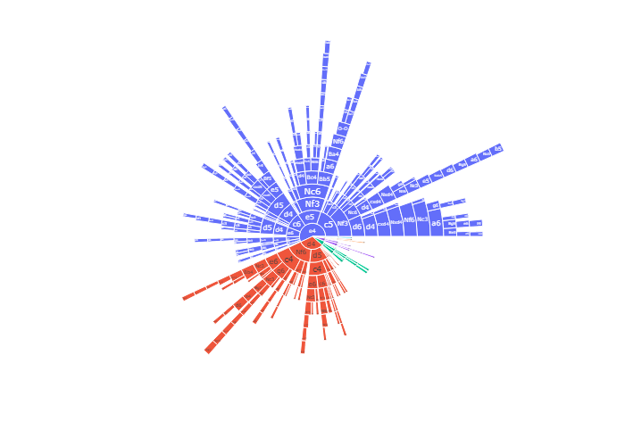

### Season awards 🏆

Because winning isn’t everything; it’s the only thing :)

See the footnote for further details on each award.[^7]

| Award | Name / Description | Winner(s) | Runner(s)-up |
| --- | --- | --- | --- |
| x | Aces | c("El_Pollo_Diablo", "wernhao", "Impaired", "oleksiial", "ssyx", "davegiltinan", "espnjosh", "Like-a-hurricane", "mikibene", "pepehands321", "Radmankaruf", "Yakruna30") |  |
| x | Archbishop of Accuracy | bluberrie_tea | MoistvonLipwig, Like-a-hurricane |
| x | Awesome Alt | jacade | invinci7777, milanrad, palet_master (4) |
| x | Bullet Boss | arthi15 | Bisit, blindfoldcheese |
| x | David Award | newttarGaerYon | bluberrie_tea, xandic |
| x | Egalitarian Award | Duda, where's my Carlsen? |  |
| x | Gambit Guru | MrScribbles | BattleAxiom, KaperKK |
| x | Giri Award | TimothyHa |  |
| x | Grischuk's Cousin | Merkava777 | Hindemith, thiccclouds |
| x | Houdini Award | wernhao | ssyx, davegiltinan |

[output cut: 10 more lines]

### All the stats!

All the following tables are sortable and searchable.

#### Team statistics

| rank | Team | games | points | pts_nonforf | wins | draws | losses | players | avg_moves | ACPL | blunder_pc |
| --- | --- | --- | --- | --- | --- | --- | --- | --- | --- | --- | --- |
| 1 | Positional King Sacrifice | 78 | 47.5 | 45.5 | 39 | 13 | 26 | 13 | 40.025641025641 | 44.0060858424087 | 3.77962844330557 |
| 2 | The ShawShankland Redemption | 75 | 43 | 39.5 | 34 | 11 | 30 | 14 | 40.64 | 45.3034776902887 | 5.05249343832021 |
| 3 | Duda, where's my Carlsen? | 79 | 49 | 48 | 44 | 8 | 27 | 10 | 39.5569620253165 | 42.7504 | 3.584 |
| 4 | Humble Pawns | 75 | 51.5 | 47 | 39 | 16 | 20 | 14 | 41.0266666666667 | 43.6074098147546 | 4.22489437764056 |
| 5 | Lichess Diamond Members | 77 | 47 | 44 | 38 | 12 | 27 | 13 | 43.5714285714286 | 46.6038748137109 | 4.9478390461997 |
| 6 | Fish, chips, cup o' tea, bad food, worse weather, Mary Poppins | 75 | 45.5 | 41 | 36 | 10 | 29 | 14 | 38.8933333333333 | 42.0527939664038 | 4.83373328762427 |
| 7 | Tempo Tantrums | 78 | 43.5 | 42 | 37 | 10 | 31 | 11 | 37.1025641025641 | 49.0272978576365 | 4.97581202487906 |
| 8 | @glbert has left the channel | 77 | 42.5 | 41 | 37 | 8 | 32 | 23 | 37.4285714285714 | 47.7307425399028 | 5.27411519777932 |
| 9 | Duda, where's my Karjakin? | 76 | 43.5 | 39.5 | 35 | 9 | 32 | 12 | 37.4473684210526 | 52.1018973998595 | 5.37596626844694 |
| 10 | Tima's Titans | 79 | 43.5 | 42.5 | 34 | 17 | 28 | 12 | 42.3670886075949 | 42.4672841350463 | 4.18285031371377 |

[output cut: 32 more lines]

#### Best performances / highest accuracy

##### Best relative perfs

Shows players’ *relative* performance ratings: season performance rating minus initial rating.[^8]

*Includes all players with a positive relative performance rating over at least five games.*

| # | Player | Games | W | D | L | Initial | Perf | Diff. |
| --- | --- | --- | --- | --- | --- | --- | --- | --- |
| 1 | oleksiial | 7 | 7 | 0 | 0 | 1905 | 2802.85714285714 | 897.857142857143 |
| 2 | ssyx | 7 | 7 | 0 | 0 | 1670 | 2515.28571428571 | 845.285714285714 |
| 3 | tmac12390 | 5 | 5 | 0 | 0 | 1607 | 2416.6 | 809.6 |
| 4 | El_Pollo_Diablo | 8 | 8 | 0 | 0 | 1719 | 2510.125 | 791.125 |
| 5 | Ajolote4 | 5 | 5 | 0 | 0 | 2297 | 3045 | 748 |
| 6 | ze_oNe | 5 | 5 | 0 | 0 | 1828 | 2572.8 | 744.8 |
| 7 | Yakruna30 | 8 | 7 | 0 | 1 | 1405 | 1824.375 | 419.375 |
| 8 | wernhao | 10 | 9 | 0 | 1 | 1624 | 2029.8 | 405.8 |
| 9 | davegiltinan | 7 | 6 | 1 | 0 | 1517 | 1900.28571428571 | 383.285714285714 |
| 10 | Radmankaruf | 8 | 7 | 0 | 1 | 1901 | 2272 | 371 |

[output cut: 179 more lines]

##### Lowest ACPL

*Includes the 100 players with the lowest ACPL (min. 100 moves played).*

| Rank | Player | Games | ACPL | Lichess ACPL |
| --- | --- | --- | --- | --- |
| 1 | bluberrie_tea | 8 | 22.6015037593985 | 18.5438596491228 |
| 2 | MoistvonLipwig | 6 | 26.8738738738739 | 16.395256916996 |
| 3 | Like-a-hurricane | 8 | 28.2387096774194 | 22.2354838709677 |
| 4 | FirstnameLastname | 7 | 31.1129032258065 | 25.1992619926199 |
| 5 | Okoros | 7 | 32.0613496932515 | 21.7192429022082 |
| 6 | rezoons | 7 | 32.6206896551724 | 23.9037800687285 |
| 7 | washedup0810 | 8 | 32.7442922374429 | 21.4719387755102 |
| 8 | chessfish2 | 8 | 35.9183673469388 | 24.5942408376963 |
| 9 | Chordaty | 6 | 36 | 29.9317269076305 |
| 10 | Silkthewanderer | 8 | 36.1162790697674 | 24.9742765273312 |

[output cut: 70 more lines]

#### Time spent / strongest opponents

##### Time spent

*Includes the 50 players who spent the most clock time over the season.*

| Rank | Player | Games | Total time spent |
| --- | --- | --- | --- |
| 1 | Juggles8 | 8 | 10h 3m 15s |
| 2 | Ringelnatz | 8 | 9h 55m 21s |
| 3 | washedup0810 | 8 | 9h 53m 58s |
| 4 | thiccclouds | 8 | 9h 49m 38s |
| 5 | rock840 | 8 | 9h 47m 41s |
| 6 | adande1 | 8 | 9h 46m 43s |
| 6 | Lupo_Jones | 8 | 9h 46m 43s |
| 7 | KS_Legion_Legionowo | 8 | 9h 45m 49s |
| 8 | mini_karpov | 8 | 9h 37m 40s |
| 9 | JustChillJoe | 8 | 9h 32m 49s |

[output cut: 40 more lines]

##### Time spent per move (after move 10)

*Includes everyone who played at least three games.*

| Rank | Player | Games | Moves | Time spent per move | Percentile |
| --- | --- | --- | --- | --- | --- |
| 1 | myle | 6 | 110 | 2m 41.2s | 100 |
| 2 | FlyingDog | 3 | 34 | 2m 33.6s | 100 |
| 3 | Mackjalek97 | 6 | 89 | 2m 31.8s | 100 |
| 4 | ATrueRavenclaw | 7 | 155 | 2m 27.0s | 100 |
| 5 | Idiocracy | 7 | 129 | 2m 21.1s | 99 |
| 6 | floating_point | 8 | 200 | 2m 19.0s | 99 |
| 7 | root2 | 8 | 176 | 2m 16.9s | 99 |
| 8 | nagdingbrob | 8 | 144 | 2m 13.9s | 99 |
| 9 | WarGoblin | 4 | 95 | 2m 13.5s | 98 |
| 10 | Midnightokar | 8 | 198 | 2m 13.2s | 98 |

[output cut: 429 more lines]

##### Strength of schedule

These players faced the most in-form opponents across the season, when judged by their opponents’ collective score in all their other games.[^9]

*Includes all players who faced a collective group of opponents that played at least 15 (other) games across the season with a collective score above 50 per cent.*

| # | Player | Opp Games | Opp Pts | Opp % |
| --- | --- | --- | --- | --- |
| 1 | newttarGaerYon | 20 | 15 | 75 |
| 2 | bluberrie_tea | 42 | 31 | 73.8095238095238 |
| 3 | xandic | 27 | 19 | 70.3703703703704 |
| 4 | cilha0 | 30 | 21 | 70 |
| 4 | rezoons | 35 | 24.5 | 70 |
| 5 | AndyBarkers | 47 | 32.5 | 69.1489361702128 |
| 6 | Maxikrassen | 21 | 14.5 | 69.0476190476191 |
| 7 | UpGoerFive | 47 | 32 | 68.0851063829787 |
| 8 | masedog91 | 36 | 24.5 | 68.0555555555556 |
| 9 | l177 | 44 | 29.5 | 67.0454545454545 |

[output cut: 212 more lines]

#### Comebacks and upsets

##### Comebacks

*Includes players with a positive average “comeback margin” that played at least three games.*[^10]

| Rank | Player | Average Comeback Margin | Total Comeback Margin |
| --- | --- | --- | --- |
| 1 | wernhao | 1.12621976587054 | 11.2621976587054 |
| 2 | ssyx | 1.47332361916672 | 10.313265334167 |
| 3 | davegiltinan | 1.38295593986891 | 9.68069157908237 |
| 4 | El_Pollo_Diablo | 1.19963298754369 | 9.59706390034954 |
| 5 | oleksiial | 1.36145717661825 | 9.53020023632777 |
| 6 | Yakruna30 | 1.17437810697749 | 9.39502485581993 |
| 7 | Bebetter14 | 1.16188859922774 | 9.29510879382194 |
| 8 | Radmankaruf | 1.13536564880946 | 9.08292519047568 |
| 9 | JocelynHeckenkamp | 1.1260562493366 | 9.00844999469277 |
| 10 | MrScribbles | 1.1187841892828 | 8.95027351426242 |

[output cut: 425 more lines]

##### Biggest upsets

*Includes all players who defeated an opponent rated at least 50 points higher.*

| Rank | Player | Upset Margin |
| --- | --- | --- |
| 1 | Ezze_13 | 366 |
| 2 | Rskyoz | 322 |
| 3 | Ezze_13 | 258 |
| 4 | wernervolkmann | 196 |
| 5 | BigEvo8 | 190 |
| 5 | Dead_Vanguard | 190 |
| 6 | AlexGaul | 186 |
| 7 | wernervolkmann | 173 |
| 8 | wernhao | 164 |
| 9 | BFS127 | 159 |

[output cut: 185 more lines]

##### Repeated upsets

Includes players who achieved multiple wins over opponents rated at least 50 points higher.

| Rank | Player | Total Upset Margin | Upsets | Avg Upset Margin | Biggest Margin |
| --- | --- | --- | --- | --- | --- |
| 1 | Ezze_13 | 735 | 3 | 245 | 366 |
| 2 | wernervolkmann | 369 | 2 | 184.5 | 196 |
| 3 | BFS127 | 340 | 3 | 113.333333333333 | 159 |
| 4 | chatakkuma | 296 | 3 | 98.6666666666667 | 116 |
| 5 | electricfalcon | 295 | 2 | 147.5 | 157 |
| 5 | Marc999 | 295 | 2 | 147.5 | 159 |
| 6 | nerja25390 | 271 | 3 | 90.3333333333333 | 126 |
| 6 | rezoons | 271 | 2 | 135.5 | 140 |
| 7 | netherfiel | 261 | 3 | 87 | 145 |
| 8 | AlexGaul | 248 | 2 | 124 | 186 |

[output cut: 24 more lines]

#### Dawdlers and instant movers

##### Least time left after move 10

The players with the least time left after 10 moves…who still managed to win![^11]

| Rank | Player | Time left after 10 moves | Link |
| --- | --- | --- | --- |
| 1 | Merkava777 | 11m 26s | https://lichess.org/rF9Cmybk#20 |
| 2 | Hindemith | 13m 4s | https://lichess.org/EKTIMXtz#20 |
| 3 | thiccclouds | 13m 23s | https://lichess.org/wi0mjtzu#20 |
| 4 | SlimyOctopus | 13m 24s | https://lichess.org/NvRK5kNt#19 |
| 4 | Sqlc | 13m 24s | https://lichess.org/tedSjCNB#19 |
| 5 | ben622 | 13m 31s | https://lichess.org/3Bz9XZTG#20 |
| 6 | sb_362 | 14m 55s | https://lichess.org/1nPoRZvq#20 |
| 7 | et5555yang | 15m 31s | https://lichess.org/bS5q72Rs#20 |
| 8 | caodanny | 16m 56s | https://lichess.org/QlVvNoon#19 |
| 9 | Seb32 | 18m 52s | https://lichess.org/i7aPIAhm#20 |

##### Instant moves

Players who made the most ‘instant’ moves over the season, taking less than 0.5 seconds (includes premoves).

*Includes players with more than five ‘instant’ moves.*

| Rank | Player | Instant moves |
| --- | --- | --- |
| 1 | arthi15 | 25 |
| 1 | Bisit | 25 |
| 1 | blindfoldcheese | 25 |
| 2 | sahkal | 23 |
| 3 | washedup0810 | 21 |
| 4 | VicPyrrhic | 20 |
| 5 | JensenUVA | 19 |
| 6 | Brentalor | 18 |
| 6 | Juggles8 | 18 |
| 7 | oleksiial | 17 |

[output cut: 90 more lines]

#### Longest thinks, time trouble addicts, and lucky escapes

##### Longest thinks

The longest times spent on a single move.

*Top 100 shown.*

| # | Player | Time spent | Colour | Move | Link |
| --- | --- | --- | --- | --- | --- |
| 1 | bufferunderrun | 40m 45s | White | 17 | https://lichess.org/bdh61nRm#33 |
| 2 | mgold | 31m 55s | Black | 22 | https://lichess.org/3RzN6YvI#44 |
| 3 | adrienb96 | 30m 50s | White | 23 | https://lichess.org/Qs4dpL2W#45 |
| 4 | pepepibote | 30m 30s | Black | 13 | https://lichess.org/cVAzRF3g#26 |
| 5 | bufferunderrun | 28m 35s | White | 17 | https://lichess.org/Ssfs2DfM#33 |
| 6 | pepepibote | 28m 30s | Black | 11 | https://lichess.org/U44tltgR#22 |
| 7 | thiccclouds | 27m 31s | Black | 8 | https://lichess.org/wi0mjtzu#16 |
| 8 | antazhi8 | 25m 32s | Black | 14 | https://lichess.org/oiiuLFbV#28 |
| 9 | mronemore | 25m 18s | White | 19 | https://lichess.org/Z2KUXBbv#37 |
| 10 | kostasvl | 25m 17s | White | 12 | https://lichess.org/eXgKO3ai#23 |

[output cut: 90 more lines]

##### Time trouble addicts

Shows players by proportion of moves made in time trouble (defined as having less than a minute remaining on the clock).

*Includes everyone who played at least 100 moves over the season while making at least one move in time trouble.*

| # | Player | All moves | With < 1min left | Time Trouble % |
| --- | --- | --- | --- | --- |
| 1 | lion88 | 121 | 57 | 0.471074380165289 |
| 2 | texaspete09 | 355 | 141 | 0.397183098591549 |
| 3 | pepepibote | 267 | 84 | 0.314606741573034 |
| 4 | Sesquipedalism | 107 | 33 | 0.308411214953271 |
| 5 | Hindemith | 297 | 90 | 0.303030303030303 |
| 6 | Fishmoro | 316 | 86 | 0.272151898734177 |
| 7 | KaiM_03 | 258 | 64 | 0.248062015503876 |
| 8 | AACtrl | 341 | 76 | 0.222873900293255 |
| 9 | ehGolden | 311 | 68 | 0.218649517684887 |
| 10 | rodeo | 271 | 51 | 0.188191881918819 |

[output cut: 218 more lines]

##### Saved by the bell

Players who made moves with under 5 seconds left on their clock…and still won![^12]

| Player | Moves with under 5s left | Least time left | Link |
| --- | --- | --- | --- |
| ripvine | 4 | 1 | https://lichess.org/yWk6qJu5 |
| Lelouch_Vi_Brittania | 4 | 3 | https://lichess.org/jKjiR3ZM |
| wizzywop | 3 | 1 | https://lichess.org/F1N8qGWp |
| Hindemith | 2 | 5 | https://lichess.org/EKTIMXtz |
| dave3 | 1 | 2 | https://lichess.org/kzSDkbTg |
| ehGolden | 1 | 3 | https://lichess.org/G7ZXbKu0 |
| lc91 | 1 | 3 | https://lichess.org/WgvD0fJq |
| Fishmoro | 1 | 3 | https://lichess.org/DtkfysYR |
| aloo_bhaloo | 1 | 4 | https://lichess.org/SThdeu4n |
| pepepibote | 1 | 4 | https://lichess.org/hYgHlxbx |

[output cut: 5 more lines]

#### Misc. facts

##### Lesser spotted mates

A pawn gave checkmate in 6 games: https://lichess.org/mCPCrmhW, https://lichess.org/9lalRqKC, https://lichess.org/7yY9CoPf, https://lichess.org/NvRK5kNt, https://lichess.org/GyRMrzip, https://lichess.org/leigYpI5.

A knight gave checkmate in 8 games: https://lichess.org/rgh6juxn, https://lichess.org/h0p9gy1Q, https://lichess.org/RG3MVV7A, https://lichess.org/8pz6sx3a, https://lichess.org/LVz7Sgku, https://lichess.org/IvBHuSbi, https://lichess.org/hBJvbz47, https://lichess.org/5UEHQck1.